# DAB300_ML_Lab_1_keras_Group17_Submission

## DAB300 - LAB 1 - GROUP NUMBER: 17

- Meghaben - W0749147
- Vipin - W755900
- Yasmin - W0754285
- Urmi - W0756341
- Trang Bui - W0753523

# Lab 1: A first look at a neural network

**This is a modified version of the original notebook by Francois Chollet.**

We will now take a look at a first concrete example of a neural network, which makes use of the Python library Keras to learn to classify hand-written digits. Unless you already have experience with Keras or similar libraries, you will not understand everything about this first example right away. Don't worry, that is perfectly fine. We've got to start somewhere.

The problem we are trying to solve here is to classify grayscale images of handwritten digits (28 pixels by 28 pixels), into their 10 categories (0 to 9). The dataset we will use is the MNIST dataset, a classic dataset in the machine learning community, which has been around for almost as long as the field itself and has been very intensively studied. It's a set of 60,000 training images, plus 10,000 test images, assembled by the National Institute of Standards and Technology (the NIST in MNIST) in the 1980s. You can think of "solving" MNIST as the "Hello World" of deep learning -- it's what you do to verify that your algorithms are working as expected. As you become a machine learning practitioner, you will see MNIST come up over and over again, in scientific papers, blog posts, and so on.

The MNIST dataset comes pre-loaded in Keras, in the form of a set of four Numpy arrays:

```python
from tensorflow.keras.datasets import mnist

(train_images, train_labels), (test_images, test_labels) = mnist.load_data()
```

`train_images` and `train_labels` form the "training set", the data that the model will learn from. The model will then be tested on the "test set", `test_images` and `test_labels`. Our images are encoded as Numpy arrays, and the labels are simply an array of digits, ranging from 0 to 9. There is a one-to-one correspondence between the images and the labels.

Let's have a look at the training data:

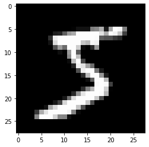

```python
import matplotlib.pyplot as plt

plt.imshow(train_images[0], cmap='gray')
```

```python
train_images.shape
```

```
(60000, 28, 28)
```

```python
train_images[0] # the first image
```

```
array([[  0,   0,   0,   0,   0,   0,   0,   0,   0,   0,   0,   0,   0,
          0,   0,   0,   0,   0,   0,   0,   0,   0,   0,   0,   0,   0,
          0,   0],
       [  0,   0,   0,   0,   0,   0,   0,   0,   0,   0,   0,   0,   0,
          0,   0,   0,   0,   0,   0,   0,   0,   0,   0,   0,   0,   0,
          0,   0],
       [  0,   0,   0,   0,   0,   0,   0,   0,   0,   0,   0,   0,   0,
          0,   0,   0,   0,   0,   0,   0,   0,   0,   0,   0,   0,   0,
          0,   0],
       [  0,   0,   0,   0,   0,   0,   0,   0,   0,   0,   0,   0,   0,
          0,   0,   0,   0,   0,   0,   0,   0,   0,   0,   0,   0,   0,
          0,   0],
       [  0,   0,   0,   0,   0,   0,   0,   0,   0,   0,   0,   0,   0,
          0,   0,   0,   0,   0,   0,   0,   0,   0,   0,   0,   0,   0,
          0,   0],
       [  0,   0,   0,   0,   0,   0,   0,   0,   0,   0,   0,   0,   3,
         18,  18,  18, 126, 136, 175,  26, 166, 255, 247, 127,   0,   0,
          0,   0],
       [  0,   0,   0,   0,   0,   0,   0,   0,  30,  36,  94, 154, 170,
        253, 253, 253, 253, 253, 225, 172, 253, 242, 195,  64,   0,   0,
          0,   0],
       [  0,   0,   0,   0,   0,   0,   0,  49, 238, 253, 253, 253, 253,
        253, 253, 253, 253, 251,  93,  82,  82,  56,  39,   0,   0,   0,
          0,   0],
       [  0,   0,   0,   0,   0,   0,   0,  18, 219, 253, 253, 253, 253,
        253, 198, 182, 247, 241,   0,   0,   0,   0,   0,   0,   0,   0,
          0,   0],
       [  0,   0,   0,   0,   0,   0,   0,   0,  80, 156, 107, 253, 253,
        205,  11,   0,  43, 154,   0,   0,   0,   0,   0,   0,   0,   0,
          0,   0],
       [  0,   0,   0,   0,   0,   0,   0,   0,   0,  14,   1, 154, 253,
         90,   0,   0,   0,   0,   0,   0,   0,   0,   0,   0,   0,   0,
          0,   0],
       [  0,   0,   0,   0,   0,   0,   0,   0,   0,   0,   0, 139, 253,
        190,   2,   0,   0,   0,   0,   0,   0,   0,   0,   0,   0,   0,
          0,   0],
       [  0,   0,   0,   0,   0,   0,   0,   0,   0,   0,   0,  11, 190,
        253,  70,   0,   0,   0,   0,   0,   0,   0,   0,   0,   0,   0,
          0,   0],
       [  0,   0,   0,   0,   0,   0,   0,   0,   0,   0,   0,   0,  35,
```

[output cut: 29 more lines]

```
       [  0,   0,   0,   0,  55, 172, 226, 253, 253, 253, 253, 244, 133,
         11,   0,   0,   0,   0,   0,   0,   0,   0,   0,   0,   0,   0,
          0,   0],
       [  0,   0,   0,   0, 136, 253, 253, 253, 212, 135, 132,  16,   0,
          0,   0,   0,   0,   0,   0,   0,   0,   0,   0,   0,   0,   0,
          0,   0],
       [  0,   0,   0,   0,   0,   0,   0,   0,   0,   0,   0,   0,   0,
          0,   0,   0,   0,   0,   0,   0,   0,   0,   0,   0,   0,   0,
          0,   0],
       [  0,   0,   0,   0,   0,   0,   0,   0,   0,   0,   0,   0,   0,
          0,   0,   0,   0,   0,   0,   0,   0,   0,   0,   0,   0,   0,
          0,   0],
       [  0,   0,   0,   0,   0,   0,   0,   0,   0,   0,   0,   0,   0,
          0,   0,   0,   0,   0,   0,   0,   0,   0,   0,   0,   0,   0,
          0,   0]], dtype=uint8)
```

```python
train_images[0].shape  # the shape of the first image
```

```
(28, 28)
```

```python
len(train_labels)
```

```
60000
```

```python
train_labels[:6] # first 5 labels
```

```
array([5, 0, 4, 1, 9, 2], dtype=uint8)
```

Let's have a look at the test data:

```python
test_images.shape
```

```
(10000, 28, 28)
```

```python
len(test_labels)
```

```
10000
```

```python
test_labels
```

```
array([7, 2, 1, ..., 4, 5, 6], dtype=uint8)
```

Before training, we will preprocess our data by reshaping it into the shape that the network expects, and scaling it so that all values are in the `[0, 1]` interval. Previously, our training images for instance were stored in an array of shape `(60000, 28, 28)` of type `uint8` with values in the `[0, 255]` interval. We transform it into a `float32` array of shape `(60000, 28 * 28)` with values between 0 and 1.

```python
train_images = train_images.astype('float32') / 255
train_images = train_images.reshape((60000, 28 * 28))

test_images = test_images.astype('float32') / 255
test_images = test_images.reshape((10000, 28 * 28))
```

### Reshaping an image for the network

The picture below shows the steps involved in converting a 10x10 pixel image into a 1 dimensional array that can be fed into a fully-connected neural network (assuming we do not scale the pixel values).

[figure not shown]

And the picture below should help you visualize what things look like when we consider more than a single sample in our data:

[figure not shown]

We also need to categorically encode the labels:

```python
from tensorflow.keras.utils import to_categorical

train_labels = to_categorical(train_labels)
test_labels = to_categorical(test_labels)
```

```python
train_labels[:5]
```

```
array([[0., 0., 0., 0., 0., 1., 0., 0., 0., 0.],
       [1., 0., 0., 0., 0., 0., 0., 0., 0., 0.],
       [0., 0., 0., 0., 1., 0., 0., 0., 0., 0.],
       [0., 1., 0., 0., 0., 0., 0., 0., 0., 0.],
       [0., 0., 0., 0., 0., 0., 0., 0., 0., 1.]], dtype=float32)
```

[figure not shown]

Our workflow will be as follow: first we will present our neural network with the training data, `train_images` and `train_labels`. The network will then learn to associate images and labels. Finally, we will ask the network to produce predictions for `test_images`, and we will verify if these predictions match the labels from `test_labels`.

## Build the network

Let's build our network -- again, remember that you aren't supposed to understand everything about this example just yet.

```python
from tensorflow.keras.models import Sequential
from tensorflow.keras.layers import Dense

network = Sequential()
network.add(Dense(512, activation='relu', input_shape=(28 * 28,)))
network.add(Dense(10, activation='softmax'))
```

The core building block of neural networks is the "layer", a data-processing module which you can conceive as a "filter" for data. Some data comes in, and comes out in a more useful form. Precisely, layers extract *representations* out of the data fed into them -- hopefully representations that are more meaningful for the problem at hand. Most of deep learning really consists of chaining together simple layers which will implement a form of progressive "data distillation". A deep learning model is like a sieve for data processing, made of a succession of increasingly refined data filters -- the "layers".

Here our network consists of a sequence of two `Dense` layers, which are densely-connected (also called "fully-connected") neural layers. The second (and last) layer is a 10-way "softmax" layer, which means it will return an array of 10 probability scores (summing to 1). Each score will be the probability that the current digit image belongs to one of our 10 digit classes. See this [blog post](https://victorzhou.com/blog/softmax/) for more details on the softmax function. The following picture may help you see what is happening:

[figure not shown]

To make our network ready for training, we need to pick three more things, as part of "compilation" step:

- A loss function: this is how the network will be able to measure how good a job it is doing on its training data, and thus how it will be able to steer itself in the right direction.
- An optimizer: this is the mechanism through which the network will update its parameters (weights and biases) based on the data it sees and its loss function. This is like the *gradient descent* recipe for updating the network's parameters.
- Metrics: what to monitor during training and testing. Here we will only care about accuracy (the fraction of the images that were correctly classified).

## Compile the network

```python
network.compile(optimizer='rmsprop',
                loss='categorical_crossentropy',
                metrics=['accuracy'])
```

We are now ready to train our network, which in Keras is done via a call to the `fit` method of the network: we "fit" the model to its training data.

## Fit the data

```python
history = network.fit(train_images, train_labels, epochs=5, batch_size=128, verbose=1)
```

```
Train on 60000 samples
```

Two quantities are being displayed during training: the "loss" of the network over the training data, and the accuracy of the network over the training data.

We quickly reach an accuracy of 0.989 (i.e. 98.9%) on the training data.

## Check test accuracy

Now let's check that our model performs well on the test set too:

```python
test_loss, test_acc = network.evaluate(test_images, test_labels)
```

```python
print('test_acc:', test_acc)
```

```
test_acc: 0.98
```

Our test set accuracy turns out to be around 98%, which is lower than the training set accuracy. This gap between training accuracy and test accuracy is an example of "overfitting", the fact that machine learning models tend to perform worse on new data than on their training data.

This concludes our very first example -- you just saw how we could build and train a neural network to classify handwritten digits, in less than 20 lines of Python code.

**epoch**

- one epoch is reached when all training examples have been sent through the network

**batch size**

- the training data is not sent through the network one at time but in batches; this is another hyperparamter to be set. In this example the batch size was set to 128

## Your turn

Rerunning the network means executing the following steps:

- Build the network
- Compile the network
- Fit the data
- Check test accuracy

**For each exercise, first make a complete copy of the `network` in the *Build the network* section and then modify according to the exercise instructions.**

### Exercise 1 (5 marks)

- change the activation in the hidden layer to 'sigmoid'
- rerun the network
- what is the new value for the training accuracy?
- what is the new value for the test accuracy?

```python
# Build the network
from tensorflow.keras.models import Sequential
from tensorflow.keras.layers import Dense

network1 = Sequential()
network1.add(Dense(512, activation='sigmoid', input_shape=(28 * 28,)))
network1.add(Dense(10, activation='softmax'))
```

```python
# Compile the network
network1.compile(optimizer='rmsprop',
                loss='categorical_crossentropy',
                metrics=['accuracy'])
```

```python
# Fit the data
history = network1.fit(train_images, train_labels, epochs=5, batch_size=128, verbose=1)
```

```
Train on 60000 samples
```

```python
# Check test accuracy
test_loss, test_acc = network1.evaluate(test_images, test_labels)
print('test_acc:', test_acc)
```

```
test_acc: 0.9681
```

#### Conclusion

- The new value for the training accuracy is 0.9675 (i.e. 96.75%)
- The new value for the test accuracy is 0.9681 (i.e. 96.81%)
- For the created network with sigmoid function here our training dataset accuracy is around 96.75% and our test dataset accuracy turns out to be around 96.81%, which is a little better than the training dataset accuracy.
- This concludes that with sigmoid function network performance is get a little better with test dataset.

### Exercise 2 (5 marks)

- change the activation in the hidden layer back to 'relu'
- change the batch size to 32
- rerun the network
- what is the new value for the training accuracy?
- what is the new value for the test accuracy?
- was the speed effected?

```python
# Build the network
network2 = Sequential()
network2.add(Dense(512, activation='relu', input_shape=(28 * 28,)))
network2.add(Dense(10, activation='softmax'))
```

```python
# Compile the network
network2.compile(optimizer='rmsprop',
                loss='categorical_crossentropy',
                metrics=['accuracy'])
```

```python
# Fit the data
history = network2.fit(train_images, train_labels, epochs=5, batch_size=32, verbose=1)
```

```
Train on 60000 samples
```

```python
# Check test accuracy
test_loss, test_acc = network2.evaluate(test_images, test_labels)
print('test_acc:', test_acc)
```

```
test_acc: 0.9781
```

#### Conclusion

- The new value for the training accuracy is 0.9892 (i.e. 98.92%)
- The new value for the test accuracy is 0.9781 (i.e. 97.81%)
- The speed is 3 times slower than previous network, it's 15s comparing to 5s-6s of previous network execution.
- In the given exercise 2 the trained set has the accuracy around of 98.92% and for test set,accuracy is around 97.81%, which is less than the trained set accuracy.
- With ReLU activation function and batch size of 32 test set is less accurate than trained set which is the case of overfitting.

### Exercise 3 (5 marks)

- change the number of epochs to 10
- rerun the network
- what is the new value for the training accuracy?
- what is the new value for the test accuracy?

```python
# build the network
network3 = Sequential()
network3.add(Dense(512, activation='relu', input_shape=(28 * 28,)))
network3.add(Dense(10, activation='softmax'))
```

```python
# Compile the network
network3.compile(optimizer='rmsprop',
                loss='categorical_crossentropy',
                metrics=['accuracy'])
```

```python
# Fit the data
history = network3.fit(train_images, train_labels, epochs=10, batch_size=32, verbose=1)
```

```
Train on 60000 samples
```

```python
# Check test accuracy
test_loss, test_acc = network3.evaluate(test_images, test_labels)
print('test_acc:', test_acc)
```

```
test_acc: 0.9803
```

#### Conclusion

- The new value for the training accuracy is 0.9992.(i.e., 99.92%)
- The new value for the test accuracy is 0.9803. (i.e., 98.03%)
- The trained set has the accuracy around of 99.92% and for test set, accuracy is around 98.03%, which is less than the trained set accuracy.
- With ReLU activation function and batch size of 32 and changed epochs to 10, the test set is less accurate than trained set which is the case of overfitting.

### Exercise 4 (5 marks)

- change the number of neurons in the hidden layer to 128
- rerun the network
- what is the new value for the training accuracy?
- what is the new value for the test accuracy?

```python
# build the network
network4 = Sequential()
network4.add(Dense(128, activation='relu', input_shape=(28 * 28,)))
network4.add(Dense(10, activation='softmax'))
```

```python
# Compile the network
network4.compile(optimizer='rmsprop',
                loss='categorical_crossentropy',
                metrics=['accuracy'])
```

```python
# Fit the data
history = network4.fit(train_images, train_labels, epochs=5, batch_size=128, verbose=1)
```

```
Train on 60000 samples
```

```python
# Check test accuracy
test_loss, test_acc = network4.evaluate(test_images, test_labels)
print('test_acc:', test_acc)
```

```
test_acc: 0.974
```

#### Conclusion

- The new value for the training accuracy is 0.9781.(i.e., 97.81%)
- The new value for the test accuracy is 0.9740.(i.e., 97.40%)
- The trained set has the accuracy around of 97.81% and for test set, accuracy is around 97.40%, which is less than the trained set accuracy.
- Here in exercise 4, with ReLU activation function and number of neurons in hidden layer is 128, the test set is less accurate than trained set which is the case of overfitting.

### Exercise 5 (10 marks)

- to the original network, add a second hidden layer of 128 neurons (note that `input_shape` does note need to be set for a second *Dense* layer)
- rerun the network
- what is the new value for the training accuracy?
- what is the new value for the test accuracy?

```python
# build the network
network5 = Sequential()
network5.add(Dense(512, activation='relu', input_shape=(28 * 28,)))
network5.add(Dense(128, activation='relu'))
network5.add(Dense(10, activation='softmax'))
```

```python
# Compile the network
network5.compile(optimizer='rmsprop',
                loss='categorical_crossentropy',
                metrics=['accuracy'])
```

```python
# Fit the data
history = network5.fit(train_images, train_labels, epochs=5, batch_size=128, verbose=1)
```

```
Train on 60000 samples
```

```python
# Check test accuracy
test_loss, test_acc = network5.evaluate(test_images, test_labels)
print('test_acc:', test_acc)
```

```
test_acc: 0.9826
```

### Exercise 6 (10 marks)

There is a good chance that the network from the previous exercise is overfitting. One way to manage overfitting in a network is to add a **dropout** layer. A dropout layer will randomly "turn off" (or *drop*) a fraction of the neurons in a layer. This makes it harder for the network to 'memorize' the training data.

- add a dropout layer after the first hidden layer (see the [keras documentation](https://keras.io/layers/core/))
- rerun the network
- what is the new value for the training accuracy?
- what is the new value for the test accuracy?

```python
# build the network
from tensorflow import keras
network6 = Sequential()
network6.add(Dense(512, activation='relu', input_shape=(28 * 28,)))
keras.layers.Dropout(rate=0.5)
network6.add(Dense(128, activation='relu'))
network6.add(Dense(10, activation='softmax'))
```

```python
# Compile the network
network6.compile(optimizer='rmsprop',
                loss='categorical_crossentropy',
                metrics=['accuracy'])
```

```python
# Fit the data
history = network6.fit(train_images, train_labels, epochs=5, batch_size=128, verbose=1)
```

```
Train on 60000 samples
```

```python
# Check test accuracy
test_loss, test_acc = network6.evaluate(test_images, test_labels)
print('test_acc:', test_acc)
```

```
test_acc: 0.9777
```

## Exercise 7 - Individual Work (10 marks per group member)

**CHALLENGE:** State of the art accuracy for the MNIST dataset is 99.84%. How close can you get?

- Each group member should create a new fully-connected network. You can find information in the [keras documentation](https://keras.io/). Things to try:
  - additional layers
  - number of neurons per layer
  - batch size
  - learning rate
  - activation functions
  - weight initializations
  - different optimizers
- Each network should have at least 3 characteristics that are different from every other network submitted in this lab, which includes Exercises 1-6 and the networks created by your other group members.
- Please specify which group member created which network

### MEGHA - #0749147: Additional layer, batch size, activation function

```python
from tensorflow.keras.models import Sequential
from tensorflow.keras.layers import Dense

network7 = Sequential()
network7.add(Dense(512, activation='relu', input_shape=(28 * 28,)))
network7.add(Dense(128, activation='tanh'))
network7.add(Dense(10, activation='softmax'))
```

```python
network7.compile(optimizer='rmsprop',
                loss='categorical_crossentropy',
                metrics=['accuracy'])
```

```python
history = network7.fit(train_images, train_labels, epochs=10, batch_size=25, verbose=1)
```

```
Train on 60000 samples
```

```python
test_loss, test_acc = network7.evaluate(test_images, test_labels)
print('test_acc:', test_acc)
```

```
test_acc: 0.9761
```

```python
from tensorflow.keras.models import Sequential
from tensorflow.keras.layers import Dense

network8 = Sequential()
network8.add(Dense(256, activation='relu', input_shape=(28 * 28,)))
network8.add(Dense(10, activation='softmax'))
```

```python
network8.compile(optimizer='rmsprop',
                loss='categorical_crossentropy',
                metrics=['accuracy'])
```

```python
history = network8.fit(train_images, train_labels, epochs=20, batch_size=32, verbose=1)
```

```
Train on 60000 samples
```

```python
test_loss, test_acc = network8.evaluate(test_images, test_labels)
print('test_acc:', test_acc)
```

```
test_acc: 0.9807
```

```python
from tensorflow.keras.models import Sequential
from tensorflow.keras.layers import Dense

network9 = Sequential()
network9.add(Dense(512, activation='sigmoid', input_shape=(28 * 28,)))
network9.add(Dense(10, activation='softmax'))
```

```python
network9.compile(optimizer='rmsprop',
                loss='categorical_crossentropy',
                metrics=['accuracy'])
```

```python
history = network9.fit(train_images, train_labels, epochs=30, batch_size=15, verbose=1)
```

```
Train on 60000 samples
```

```python
test_loss, test_acc = network9.evaluate(test_images, test_labels)
print('test_acc:', test_acc)
```

```
test_acc: 0.9821
```

```python
from tensorflow.keras.models import Sequential
from tensorflow.keras.layers import Dense

network10 = Sequential()
network10.add(Dense(256, kernel_initializer='random_normal', activation='sigmoid', input_shape=(28 * 28,)))
network10.add(Dense(128, kernel_initializer='random_normal', activation='relu'))
network10.add(Dense(10, kernel_initializer='random_normal', activation='softmax'))
```

```python
network10.compile(optimizer='rmsprop',
                loss='categorical_crossentropy',
                metrics=['accuracy'])
```

```python
history = network10.fit(train_images, train_labels, epochs=15, batch_size=35, verbose=1)
```

```
Train on 60000 samples
```

```python
test_loss, test_acc = network10.evaluate(test_images, test_labels)
print('test_acc:', test_acc)
```

```
test_acc: 0.9781
```

### TRANG BUI - #0753523: additional layers, number of neurons per layer, different optimizers

#### please DO NOT re-execute below commands

#### re-executing can output different results

```python
# build the network
from tensorflow.keras.models import Sequential
from tensorflow.keras.layers import Dense
from tensorflow import keras


# build the network
print('Baseline is the Q5 to see the differences.')
print('1. Increasing number of neurons of the first layer from 512 to 1024.')
print('2. Adding 3 more hidden layers. The first added layer has 512 neurons, the second added layer has 265 neurons, and the third has 32 neurons')
print('3. Using optimizer "adam"')

network11 = Sequential()
network11.add(Dense(1024, activation='relu', input_shape=(28 * 28,)))
network11.add(Dense(512, activation='relu'))
network11.add(Dense(256, activation='relu'))
network11.add(Dense(128, activation='relu'))
network11.add(Dense(32, activation='relu'))
network11.add(Dense(10, activation='softmax'))

# Compile the network
network11.compile(optimizer='adam',
                loss='categorical_crossentropy',
                metrics=['accuracy'])

# Fit the data
history = network11.fit(train_images, train_labels, epochs=5, batch_size=128, verbose=1)
```

```
Baseline is the Q5 to see the differences.
1. Increasing number of neurons of the first layer from 512 to 1024.
2. Adding 3 more hidden layers. The first added layer has 512 neurons, the second added layer has 265 neurons, and the third has 32 neurons
3. Using optimizer "adam"
Train on 60000 samples
```

```python
# Check test accuracy
test_loss, test_acc = network11.evaluate(test_images, test_labels)
print('test_acc:', test_acc)
```

```
test_acc: 0.9814
```

- Accuracy of the train set is around 98.82% while accuracy of test set is around 98.14% => Accuracy from test phase is slightly less than accuracy in training phase.
- In comparison with the Q5, increasing number of neurons of the first hidden layer, adding 3 more hidden layers, and using optimizer "adam" (instead of "rmsprop") cannot improve the accuracy and performance. While training accuracy is 99,05% and testing accuracy is 98,26% in Q5, they are just 98,82% and 98,14% respectively in Q7 with above options. Moreover, it takes 7s to get the highest training accuracy, and 0s in testing phase in Q5 meanwhile it takes 8s to reach the highest training accuracy, and 1s in testing phase.
- However, there is one point that the gap between training accuracy and testing accuracy of network11 is less than network5's.
- In conclusion, increasing the number of neurons, adding more hidden layers, and using another optimizer are not for sure to improve accuracy and performance. Because three different characteristics are changed at the same time, so I cannot find out the main reason for not better results.